# Assignment 3

Federico Manenti 790032

# Introduction

Il problema proposto consiste nel trovare la posizione $(\chi; \nu)$ di un magazzino tale che minimizzi la distanza complessiva tra esso e 100 clienti. La posizione degli acquirenti è contenuta nel seguente dataset ed è data in coordinate $(x; y)$. I costi di costruzione del magazzino sono fissi e non dipendono dalla posizione in cui verrà costruito.

```r
df = read.csv("/home/federico/Scrivania/Università/decision_model/Assignment/Assignment_3/Testo/consumer_locations.csv")

kable(df[1:5,], align = "c") %>%
   kable_styling(bootstrap_options = "striped", full_width = F)
```

| x | y |
| --- | --- |
| 114 | 35 |
| 622 | 565 |
| 609 | 280 |
| 623 | 204 |
| 861 | 134 |

La distribuzione dei clienti è:

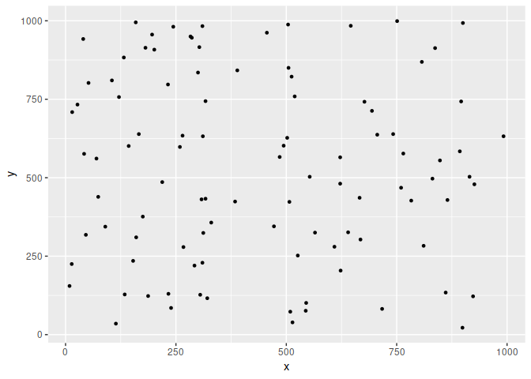

distribuzione clienti

La distanza tra il magazzino e un cliente è:

$$\begin{equation}
d = log((\chi - x_i)^2 + 1) +log((\nu - y_i)^2 + 1)
\end{equation}$$

Ragionevolmente possiamo quindi immaginare già una zona dove sarà contenuto il punto ottimale. Osservando la distribuzione dei clienti e la funzione che rappresenta la distanza, il magazzino non verrà mai costruito troppo esternamente).

# Formulate the objective function to minimize for the described problem.

La funzione obiettivo quindi è la sommatoria di tutte le distanze tra magazzino e clienti.

$$\begin{equation}
d_{tot} = \displaystyle\sum_{i=1}^{100} log((\chi - x_i)^2 + 1) +log((\nu - y_i)^2 + 1)
\end{equation}$$

Ed ha questa forma:

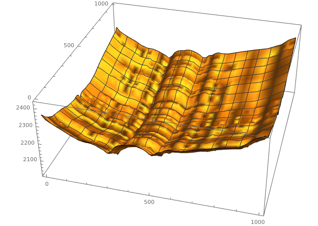

Come si può vedere la funzione ha molti minimi locali. Il metodo del gradiente discendente quindi può aiutare a risolvere il problema, ma il punto designato potrà essere un ottimo locale e non globale.

La funzione in R può essere scritta come:

```r
fun = function(chi, nu, df){
  res = 0
  for (i in c(1:nrow(df))) {
    res = (log((chi - df$x[i])^2 + 1)) + (log((nu - df$y[i])^2 + 1)) + res
  }
  return(res)
}
```

# Express in analytical form the gradient for the objective to minimize.

Il gradiente della funzione obiettivo è:

```r
gradient = function(chi, nu, df){
  res1 = 0
  res2 = 0
  for(i in c(1:nrow(df))){
    res1 = (2*(chi-df$x[i]))/((chi-df$x[i])^2 + 1) + res1
    res2 = (2*(nu-df$y[i]))/((nu-df$y[i])^2 + 1) + res2
  }
  return(c(res1, res2))
}
```

# Implement the Gradiend Descent method and solve the problem with it.

Per utilizzare il metodo del gradiente discendente servono:

- Un punto di partenza $x_k$.
- Un passo $\alpha_k$ che stabilisce di quanto la funzione si sposta all’interno della mappa ad ogni iterazione. Nelle seguenti appliczioni è stato scelto di usarlo pari a $0.01$.
- Una funzione da ottimizzare $f$.
- Il gradiente della funzione $\nabla f$.

- Il gradiente nel punto $x_{k+1}$ è nullo.
- Viene raggiunto un valore di precisione inferiore ad una soglia predeterminata.
- O come in questo caso: si raggiunge un numero massimo di iterazioni prestabilite.

Viene creata ora la funzione che permette di implementare il metodo del gradiente discendente.

```r
gradientDescent = function(df, v.init, grad, passo, iters){
  par = loss = matrix(NA, nrow = iters + 1, ncol = 2)
  par[1,] = v.init
  for(k in 1:iters){
    loss[k,] = grad(par[k,1], par[k,2], df)
    par[k+1,] = par[k,] - passo * loss[k,]       # formula del gradiente discendente
  }
  return(list(par = par))
}
```

La funzione obiettivo ha molti minimi locali, per cui il punto che verrà selezionato dal metodo dipende fortemente da quello di partenza e il risultato non per forza sarà il minimo globale. Si procede quindi a dividere la mappa in 25 zone di egual dimensione e si sceglie il punto centrale come inizio per applicare il metodo del gradiente discendente. Osservando però la funzione da minimizzare e la distribuzione dei punti ci si rende conto che il punto di ottimo globale non sarà nelle regioni laterali, per cui vengono rimosse. Ciò permette di effettuare 9 cicli anzichè 25. Infine si selezionerà come migliore il punto che tra i 9 abbia ottenuto la distanza minore.

```r
#lista di coordinate note
coord = list(c(294.9,293.1),c(294.9,488.5),c(294.9,683.9),c(491.5,293.1),c(491.5, 488.5),
             c(491.5, 683.9),c(688.1, 293.1), c(688.1, 488.5), c(688.1, 683.9))


results = data.frame(matrix(NA, ncol=3, nrow=9))
for(i in 1:9) {
  temp = as.data.frame(gradientDescent(df, coord[[i]], gradient, 0.01, iters = 1000))
  results[i,1] = tail(temp$par.1, n=1)
  results[i,2] = tail(temp$par.2, n=1)
  results[i, 3] = fun(results[i,1], results[i,2], df)
}
colnames(results) = c("X","Y", "distanza")
results_min = data.frame(x = results[which.min(results$distanza), 1],
                           y = results[which.min(results$distanza), 2], distanza = min(results$distanza))
```

Il punto che risulta dare una distanza minore quinidi è:

| x | y | distanza |
| --- | --- | --- |
| 305.6927 | 485.7431 | 2022.057 |

Il punto è già un buon minimo, ma si può provare a migliorare il rsultato utilizzandolo come punto di partenza per il metodo e verificare se nell’intorno è presente un minimo locale migliore.

```r
start = c(results_min[1,1], results_min[1,2])

prova = data.frame()
prova1 = as.data.frame(gradientDescent(df, start, gradient, 0.01, 1000))
prova[1, 1] = tail(prova1$par.1, n = 1)
prova[1, 2] = tail(prova1$par.2, n = 1)
prova[1, 3] = fun(prova[1,1], prova[1,2], df)
colnames(prova) = c("x", "y", "distanza")
```

| x | y | distanza |
| --- | --- | --- |
| 310.1627 | 485.7431 | 2016.02 |

Come possiamo vedere dalla mappa delle densità il punto individuato risulta sensato.

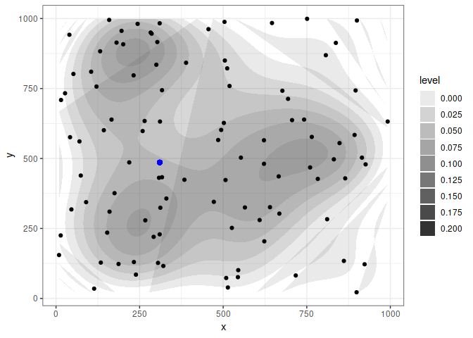

mappa densità punti

# Solve the problem with a package provided by R.

Scrivo la funzione obiettivo e il gradiente come sono necessarie per utilizzare $optimr$.

```r
fun.r = function(st){
  df = df
  res = 0
  for (i in c(1:nrow(df))) {
    res = (log((st[1] - df$x[i])^2 + 1)) + (log((st[2] - df$y[i])^2 + 1)) + res
  }
  return(res)
}

gradient.r = function(st){
  df = df
  res1 = 0
  res2 = 0
  for(i in c(1:nrow(df))){
    res1 = (2*(st[1]-df$x[i]))/((st[1]-df$x[i])^2 + 1) + res1
    res2 = (2*(st[2]-df$y[i]))/((st[2]-df$y[i])^2 + 1) + res2
  }
  return(c(res1, res2))
}
```

Viene utilizzata la funzione $optimr$ con metodo defaut per calcorare il minimo. Come punto di partenza si usa quello che tra i 9 aveva dato risultato migliore.

```r
ansfgh = optimr(par = start, fn = fun.r, gr = gradient.r)
proptimr(ansfgh)
```

```
## Result  ansfgh   proposes optimum function value = 2014.312  at parameters
## [1] 310.1595 480.7418
## After  63  fn evals, and  NA  gr evals
## Termination code is  0 :
## ---------------------------------------
```

| x | y | distanza |
| --- | --- | --- |
| 310.1595 | 480.7418 | 2014.312 |

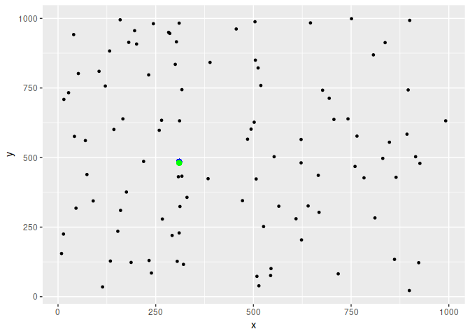

confronto 2 metodi

In questo caso optimir genera un punto vicino a quello trovato con il metodo precedente, ma comunque con una distanza molto simile.

# Implement the Stochastic gradient descent algorithm with mini-batches and use it to solve the problem.

Il metodo del gradiente discendente stocastico risulta efficace quando è presente un grande dataset perchè consiste in un campionamento e nell’applicazione del metodo su quella porzione di dati. Il procedimento permette di ridurre i tempi di esecuzione e di restituire un punto di ottimo senza che esso risulti troppo influenzato dalle osservazioni selezionate. Nel caso presentato il campionamento consiste in 15 elementi.

L’implementazione è la seguente:

```r
stoch_gradDescent = function(df, start, gradient, lr, iters){

  par = start

  parIter = data.frame(matrix(NA, nrow = iters, ncol = 2))

  set.seed(1234)


  for (i in 1:iters) {
    df_temp = data.frame(as.matrix( df[sample(nrow(df), 15), ] ))
    par = par - lr  * gradient(par[1], par[2], df_temp)
    parIter[i,] = par

 }
 return(parIter)
}
```

Come punto di partenza si è scelto di usare il solito per confrontatre i risultati ottenuti.

```r
res_stoc = stoch_gradDescent(df, start, gradient, 0.01, 1000)
res_stoc = data.frame(tail(res_stoc[, 1], 1), tail(res_stoc[,2], 1), fun(tail(res_stoc[, 1], 1), tail(res_stoc[,2], 1), df))
colnames(res_stoc)= c("chi", "nu", "distanza")
```

| chi | nu | distanza |
| --- | --- | --- |
| 306.2717 | 485.7652 | 2021.732 |

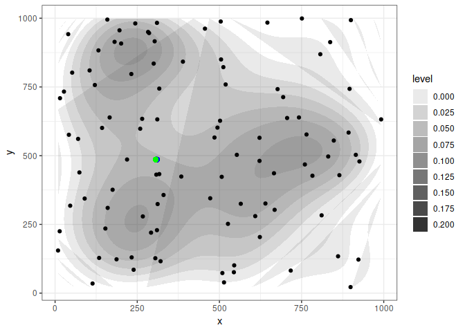

mappa densità punti

Come si vede dal grafico la soluzione ottenuta con il metodo del gradiente discendente e quella con il SGD sono quasi sovrapponibili.